# Project COVID-19

### World COVID-19 Map

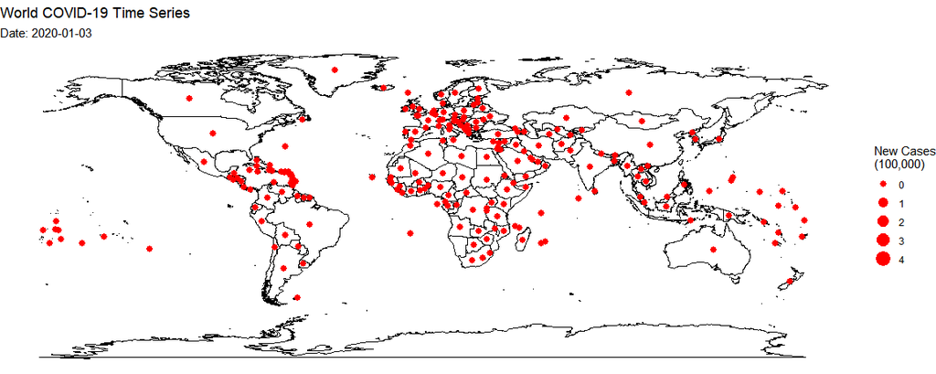

### COVID-19 World & U.S. & India Status

[figure not shown]

$\bullet$ $\textbf{Background}$  
I was interested in motion graphs in the beginning of the semester. The Corona Virus Disease - 2019 (COVID-19) is still a big issue nowadays, I thought it will be fun to make time series graphs.

$\bullet$ $\textbf{COVID-19 Timeline}$

End of 2019  
The first COVID-19 cases were detected in Wuhan, China.  
December, 2019  
Dr. Douglas Dwyer asked for detailed data about COVID-19, but it got rejected$^1$.  
31 December, 2019  
China’s Wuhan Municipal Health Commission reported that a cluster pneumonia case occurred in Wuhan City, Hubei Province$^2$.  
12 January, 2020  
China publicly shared the COVID-19 gene sequence$^2$.  
22 January, 2020  
WHO director-general Tedros Adhanom Ghebreyesus, virologists, public-health researchers, and certain government representatives did closed-door meeting and decided Public Health Emergency of International Concern (PHEIC) uncertain. However, they flipped their decision a week later$^3$.  
20 February - 7 April, 2020  
The U.S. stock market crash$^4$. Dow Jones Industrial Average (DJIA) fell about 30% (22859.6 points which are close to 2017 February points) of its value in a month$^5$.  
11 March, 2020  
WHO announced COVID-19 as a pandemic$^6$.  
13 March, 2020  
Travel ban on non-US citizens$^6$.  
19 March, 2020  
California ordered a Stay-at-Home order statewide for the first out of all the states$^6$.  
14 December, 2020  
The first COVID-19 vaccination in the U.S given to public. A nurse in New York got Pfizer vaccine$^7$.  
February - June, 2021  
The second wave in India. An average of 10,000 confirmed cases a day$^8$.  
14 May, 2021  
Centers of Disease Control (CDC) announced that fully vaccinated people don’t have to wear masks$^9$.

$\bullet$ $\textbf{Sources}$  
COVID-19 Data: [WTO COVID-19 Dashboard](https://covid19.who.int/)  
Map Coordiante Data: [thematicmapping](http://thematicmapping.org)

$^1$ https://www.bbc.com/news/world-asia-china-56054468  
$^2$ https://www.who.int/news/item/27-04-2020-who-timeline---covid-19  
$^3$ https://www.nature.com/articles/d41586-021-00162-4  
$^4$ https://en.wikipedia.org/wiki/2020_stock_market_crash  
$^5$ https://www.macrotrends.net/1319/dow-jones-100-year-historical-chart  
$^6$ https://www.ajmc.com/view/a-timeline-of-covid19-developments-in-2020  
$^7$ https://www.wsj.com/articles/covid-19-vaccinations-in-the-u-s-slated-to-begin-monday-11607941806  
$^8$ https://www.cnbc.com/2021/05/03/india-covid-crisis-charts-show-the-severity-of-the-second-wave.html  
$^9$ https://www.cnbc.com/2021/05/13/cdc-says-fully-vaccinated-people-dont-need-to-wear-face-masks-indoors-or-outdoors-in-most-settings.html